# `Momentum based trading strategy considering arbitrary number of assets`

## *Marcell Kujbus, Data and network Visualization final project, 2018.12.03*

### In this experiment we shall see the evolution of the famous Moving Average trading strategy based on arbitrary number of US stocks. Comparison is made among these and the famous buy and hold one.

*Keywords*: MA strategy, Buy and Hold strategy, Object Orientated Programming, Grid search, Randomly choosen tickers

Read more: Moving Average: How to Use it to Buy Stocks | Investopedia https://www.investopedia.com/articles/active-trading/052014/how-use-moving-average-buy-stocks.asp#ixzz5XZBG3MVj

**More detailed explanation about the work**:

1. Define the structure of the code:
   - Functions for downloading the data, and to rearrange them into pandas dataframes
   - Portfolio class to make the modelling easier and more understandable
   - Functions for evaluating the strategy
2. Examples, plots and actual evaluation
3. Conclusion

**The strategy that I implemented**:

1. Consider N asset's price chart from the US Stock Market in the same time period.
   - Initial portfolio: one share from every asset.
2. In every point when it makes sense, calculate a short MA (SMA) and a long MA (LMA).
3. Take the difference of them for every asset.
4. Whenever this difference is positive, denote the signal by a 1, otherwise it is denoted by a 0.
   - Denote the number of 0-s in the signal list with a k for every day.
   - If k < N, then sell all the shares we have from these k assets. We use the money we got in exchange.
     - Buy shares from the remaining N - k assets uniformly i.e with the same amount of money spent.
     - Repeat from step 1.
   - If k == N, then sell all the shares we have. In this step our portfolio will consist of zero shares.
     - The first time k will jump up to at least 1, invest in the k assets with the cash we have from the previous step.
   - If k == 0, don't do anything, just hold the shares.

```python
from pandas_datareader import data
import matplotlib.pyplot as plt
import pandas as pd
import matplotlib.patches as patches
import numpy as np
import datetime
import plotly
#plotly.tools.set_credentials_file(username="marcellk", api_key=)
import plotly.plotly as py
from plotly.graph_objs import *
```

```python
def DataDownloader( ticker, start, end):
    '''
    This function downloads financial data for a given company (ticker), in a
    daily basis from start to end.
    The output is a dictionary with the corresponding logreturns and the very first
    price observed.
    '''
    stock_prices = data.get_data_yahoo( ticker, start, end)
    stock_prices_null = stock_prices['Adj Close'][0]
    close = np.log(stock_prices['Adj Close']).diff().dropna()
    dict = {"logreturns" : close, "starting" : stock_prices_null}
    return dict
```

```python
#Example
aapl = DataDownloader('AAPL', "2014-10-01", "2018-10-01")
aapl['logreturns'].head(9)
print (f"One APPLE share cost {round( aapl['starting'], 2 )} dollars on 2014-10-01")
```

```
One APPLE share cost 92.1 dollars on 2014-10-01
```

```python
def SignalCreator(ticker, start, end, short, long):
    '''
    Based on the Moving Average strategy (short - long) this functions gives us the signal
    whether we should deal a long or a short position.
    1 means buying
    0 means selling
    Be warned that short << long
    '''
    price_dict = DataDownloader( ticker, start, end)
    close = price_dict['starting'] * np.exp( np.cumsum( price_dict["logreturns"] ) )
    diff = close.rolling(window = short).mean() - close.rolling(window = long).mean()
    res = diff.apply(np.sign)
    return (res + 1)/2
```

```python
def DatabaseGenerator(*args, **kwargs):
    '''
    This function creates a datatable about the trading strategy.
    Inputs: *args as arbitrary tickers g.e 'AAPL', 'MSFT', 'AMZN',....
            **kwargs as some additional info g. e start = start, end = end, short = s, long = l
    The output is a dataframe consisting of several time series.
    '''
    df = pd.DataFrame()
    for i in args:
        df[f"{i} signal"] = SignalCreator(i, kwargs['start'], kwargs['end'], kwargs['short'], kwargs['long'])
        df[f"{i} shares"] = 0
        df[f"{i} share price"] = ( DataDownloader(i, kwargs['start'], kwargs['end'])['starting']
                            * np.exp( np.cumsum( DataDownloader(i, kwargs['start'], kwargs['end'])["logreturns"] ) ))
    df = df.dropna()
    df['Cash'] = 0
    df['Share value'] = 0
    df['Wealth'] =0
    df['Buy and hold Wealth'] = 0
    for i in range(0,len(args)):
        df.iloc[0, 3*i+1] = 1
    return df
```

```python
#Example
df = DatabaseGenerator('AAPL', 'MSFT','AMZN', start = "2014-10-01", end = "2018-11-21", short = 10, long = 50)
df.head(9)
```

| Date | AAPL signal | AAPL shares | AAPL share price | MSFT signal | MSFT shares | MSFT share price | AMZN signal | AMZN shares | AMZN share price | Cash | Share value | Wealth | Buy and hold Wealth |
| --- | --- | --- | --- | --- | --- | --- | --- | --- | --- | --- | --- | --- | --- |
| 2014-12-11 | 1.0 | 1 | 104.099335 | 1.0 | 1 | 42.973427 | 1.0 | 1 | 307.359985 | 0 | 0 | 0 | 0 |
| 2014-12-12 | 1.0 | 0 | 102.336685 | 1.0 | 0 | 42.772987 | 1.0 | 0 | 307.320007 | 0 | 0 | 0 | 0 |
| 2014-12-15 | 1.0 | 0 | 100.937744 | 1.0 | 0 | 42.517899 | 0.0 | 0 | 306.070007 | 0 | 0 | 0 | 0 |
| 2014-12-16 | 1.0 | 0 | 99.557449 | 1.0 | 0 | 41.142246 | 0.0 | 0 | 295.059998 | 0 | 0 | 0 | 0 |
| 2014-12-17 | 1.0 | 0 | 102.038231 | 1.0 | 0 | 41.670639 | 0.0 | 0 | 298.880005 | 0 | 0 | 0 | 0 |
| 2014-12-18 | 1.0 | 0 | 105.059921 | 1.0 | 0 | 43.292282 | 0.0 | 0 | 297.730011 | 0 | 0 | 0 | 0 |
| 2014-12-19 | 1.0 | 0 | 104.248543 | 1.0 | 0 | 43.419827 | 0.0 | 0 | 299.899994 | 0 | 0 | 0 | 0 |
| 2014-12-22 | 1.0 | 0 | 105.330399 | 1.0 | 0 | 43.711353 | 0.0 | 0 | 306.540009 | 0 | 0 | 0 | 0 |
| 2014-12-23 | 1.0 | 0 | 104.957352 | 1.0 | 0 | 44.139545 | 0.0 | 0 | 306.290009 | 0 | 0 | 0 | 0 |

```python
def PlotPy(ticker, start, end, short, long):
    '''
    This is a function made for plotting purposes.
    The output is a 3-plot: one with logreturns,
    one with the price evolution and one is the MA difference evolution.
    '''
    price_dict = DataDownloader( ticker, start, end)
    close = price_dict['starting'] * np.exp( np.cumsum( price_dict["logreturns"] ) )

    fig, (ax1, ax2, ax3) = plt.subplots(3, 1, figsize=(16,9), sharex = True)
    ax1.plot(price_dict["logreturns"].index, price_dict["logreturns"], label=f"{ticker} logreturns")
    ax1.legend(loc = 2)
    ax1.grid(axis = "both", linestyle = '--')

    short_rolling = close.rolling(window = short).mean()
    long_rolling = close.rolling(window = long).mean()
    ax2.plot(close.index, close, label = f"{ticker} stock price")
    ax2.plot(short_rolling.index, short_rolling, label = f"{short} days rolling MA")
    ax2.plot(long_rolling.index, long_rolling, label = f"{long} days rolling MA")
    ax2.legend(loc = 2)
    ax2.grid(axis = "both", linestyle = '--')

    ax3.plot(close.index, short_rolling - long_rolling, label = f"{short} - {long} MA")
    ax3.grid(axis = "both", linestyle = '--')
    ax3.axhline(y = 0, linestyle = "-", color = "red")
    ax3.set_xlabel('Date', fontsize=16, fontweight = "bold")
    ax3.legend(loc = 2)
    start = datetime.datetime.strptime(start, "%Y-%m-%d")
    start += datetime.timedelta(days=long)
    plt.xlim((start, end))
    plt.show()
```

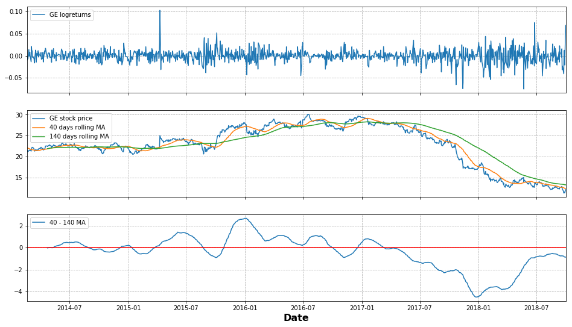

```python
#Example
PlotPy(ticker = 'GE', start = "2013-10-01", end = "2018-10-01", short = 40,long =  140)
```

```python
class Portfolio():
    '''
    This class was made to model our hypothetical investors behaviour.
    The above defined strategy was implemented in this Portfolio class.
    '''
    def __init__(self, *args):
        k = (len(args) - 1) // 3
        self.signal = [args[i] for i in range(0,k)]
        self.stock = [args[i] for i in range(k, 2* k)]
        self.price = [args[i] for i in range(2 * k, 3 * k)]
        self.number_of_long = np.sum(self.signal)
        self.cash = args[-1]
    def Value(self):
        value = 0
        for i in range(0, len(self.stock)):
            value += self.stock[i] * self.price[i]
        return value
    def __str__(self):
        return "In this round the Investor will behave according to the signals\n" \
        f"{self.signal}. Current wealth level is {self.cash + self.Value()}."

    def Business(self):
        '''
        The output of the Business method is a list consisting of the cash level, the
        stock value, and the wealth level.
        '''
        w0 = self.cash
        for i in range(0,len(self.stock)):
            if self.signal[i] == 0 and self.stock[i]:
               w0 += self.stock[i] * self.price[i]
               self.stock[i] = 0
            elif self.signal[i] ==0 and self.stock[i] ==0:
                pass
        if self.number_of_long:
            amount = w0 / self.number_of_long
            for i in range(0,len(self.stock)):
                if self.signal[i]:
                    self.stock[i] += amount / self.price[i]
            self.cash = 0
        else:
            if self.cash == 0:
                self.cash += w0
            else:
                pass
        return [self.cash, self.Value(), self.cash + self.Value()]
```

```python
#Example
p_example = Portfolio(1,0,1,0,1,0,0,1,
                      10,20, 0, 4, 5, 10, 0, 32,
                      100, 56, 231, 10, 80, 90, 42, 21, 0)
print (p_example.stock)
print('-----------------')
print (p_example.price)
print('-----------------')
print (p_example.signal)
print('-----------------')
print (p_example.number_of_long)
print('-----------------')
print (p_example.stock)
print('-----------------')
print(p_example)
print('-----------------')
print (p_example.Value())
print('-----------------')
print (p_example.Business())
```

```
[10, 20, 0, 4, 5, 10, 0, 32]
-----------------
[100, 56, 231, 10, 80, 90, 42, 21]
-----------------
[1, 0, 1, 0, 1, 0, 0, 1]
-----------------
4
-----------------
[10, 20, 0, 4, 5, 10, 0, 32]
-----------------
In this round the Investor will behave according to the signals
[1, 0, 1, 0, 1, 0, 0, 1]. Current wealth level is 4132.
-----------------
4132
-----------------
[0, 4132.0, 4132.0]
```

```python
def StrategyTrajectory(dataframe):
    '''
    This function takes a DatabaseGenerator output as an input, and it trades the
    strategy on it.
    '''
    for i in range(0, len(dataframe)):
        k = (len(dataframe.columns) - 4 ) //3
        arg = []
        for j in range(0, len(dataframe.columns) - 6, 3):
            arg.append(dataframe.iloc[i,j])
        for j in range(1,len(dataframe.columns) - 5, 3):
            arg.append(dataframe.iloc[i, j])
        for j in range(2,len(dataframe.columns) - 4, 3):
            arg.append(dataframe.iloc[i, j])
        arg.append(dataframe.iloc[i, -4])
        portf = Portfolio( *arg )
        result = portf.Business()
        dataframe.iloc[i , -4] = result[0]
        dataframe.iloc[i , -3] = result[1]
        dataframe.iloc[i, -2]  = result[2]
        if i < len(dataframe) - 1:
            dataframe.iloc[i+1, -4 ] = result[0]
            for j in range(0,k):
                dataframe.iloc[i + 1, 3*j + 1] = portf.stock[j]
        dataframe.iloc[i, -1] = np.sum([arg[i] for i in range(len(arg) - 1 - k, len(arg)-1)])
    return dataframe
```

```python
#Example1
df = StrategyTrajectory(DatabaseGenerator( 'AAPL', 'MSFT', 'GE', 'MS',
                                          start = "2014-10-01", end = "2018-10-01", short = 20, long =250))
df.head(9)
```

| Date | AAPL signal | AAPL shares | AAPL share price | MSFT signal | MSFT shares | MSFT share price | GE signal | GE shares | GE share price | MS signal | MS shares | MS share price | Cash | Share value | Wealth | Buy and hold Wealth |
| --- | --- | --- | --- | --- | --- | --- | --- | --- | --- | --- | --- | --- | --- | --- | --- | --- |
| 2015-09-29 | 0.0 | 1.0 | 103.003914 | 0.0 | 1.0 | 40.380470 | 0.0 | 1.000000 | 21.942865 | 0.0 | 1.0 | 28.912117 | 194.239367 | 0.000000 | 194.239367 | 194.239367 |
| 2015-09-30 | 0.0 | 0.0 | 104.175049 | 0.0 | 0.0 | 41.142715 | 0.0 | 0.000000 | 22.523359 | 0.0 | 0.0 | 29.368963 | 194.239367 | 0.000000 | 194.239367 | 197.210087 |
| 2015-10-01 | 0.0 | 0.0 | 103.495033 | 0.0 | 0.0 | 41.468067 | 0.0 | 0.000000 | 22.496571 | 0.0 | 0.0 | 29.368963 | 194.239367 | 0.000000 | 194.239367 | 196.828634 |
| 2015-10-02 | 0.0 | 0.0 | 104.250610 | 0.0 | 0.0 | 42.360455 | 0.0 | 0.000000 | 22.746630 | 0.0 | 0.0 | 29.303699 | 194.239367 | 0.000000 | 194.239367 | 198.661394 |
| 2015-10-05 | 0.0 | 0.0 | 104.628387 | 0.0 | 0.0 | 43.345798 | 0.0 | 0.000000 | 23.952282 | 0.0 | 0.0 | 30.105524 | 194.239367 | 0.000000 | 194.239367 | 202.031992 |
| 2015-10-06 | 0.0 | 0.0 | 105.128960 | 0.0 | 0.0 | 43.457344 | 0.0 | 0.000000 | 24.372030 | 0.0 | 0.0 | 30.170786 | 194.239367 | 0.000000 | 194.239367 | 203.129120 |
| 2015-10-07 | 0.0 | 0.0 | 104.628387 | 0.0 | 0.0 | 43.503815 | 0.0 | 0.000000 | 24.800707 | 0.0 | 0.0 | 30.702227 | 194.239367 | 0.000000 | 194.239367 | 203.635136 |
| 2015-10-08 | 0.0 | 0.0 | 103.419472 | 0.0 | 0.0 | 44.108047 | 1.0 | 0.000000 | 25.032907 | 0.0 | 0.0 | 30.758173 | 0.000000 | 194.239367 | 194.239367 | 203.318600 |
| 2015-10-09 | 0.0 | 0.0 | 105.893997 | 1.0 | 0.0 | 43.791985 | 1.0 | 7.759361 | 25.068626 | 0.0 | 0.0 | 30.506437 | 0.000000 | 194.516523 | 194.516523 | 205.261045 |

```python
#Example2
sl = [(s,l) for s in range(10, 51, 10) for l in range(50, 251, 50)]
comp = pd.DataFrame()
for i in sl:
    df = StrategyTrajectory(DatabaseGenerator('AAPL','MSFT', 'MS', 'AMZN', 'BA', 'GS', 'BLK', start = "2014-10-01",
                       end = "2018-10-01", short = i[0], long = i[1]))['Wealth']
    comp[f"{i}"] = df
buyandhold=StrategyTrajectory(DatabaseGenerator('AAPL','MSFT', 'MS', 'AMZN', 'BA', 'GS', 'BLK', start = "2014-10-01",
                       end = "2018-10-01", short = 10, long = 50))['Buy and hold Wealth']

comp['Buyandhold'] = buyandhold
```

```python
traces = {}
sl.append('BH')
for i in sl:
    if i == 'BH':
        traces['BH'] = Scatter(
        x = buyandhold.index,
        y = buyandhold,
        mode = 'lines',
        name = 'Buy and Hold',
        line = dict(width = 3))
    elif i == (40,250):
        traces[f"{i}"] = Scatter(
        x = comp[f"{i}"].index,
        y = comp[f"{i}"],
        mode = 'lines',
        line = dict(width = 3),
        name = f"{i}",
        showlegend=True)
    else:
        traces[f"{i}"] = Scatter(
        x = comp[f"{i}"].index,
        y = comp[f"{i}"],
        mode = 'lines',
        line = dict(width = .7),
        name = f"{i}",
        showlegend=False)

data = [traces[f"{i}"] for i in sl]
layout = Layout(title = "Trajectories of different MA strategies <br> assets held: AAPL, MSFT, MS, AMZN, BA, GS, BLK",
               xaxis = dict(title = 'Date',titlefont = dict(family='Times New Roman, monospace',
                                              size = 18,
                                              color = '#7f7f7f')),
               yaxis = dict(title = 'Value $',titlefont = dict(family='Times New Roman, monospace',
                                              size = 18,
                                              color = '#7f7f7f')),
               height = 700)
fig = Figure(data = data, layout = layout)
py.iplot(fig)
```

[interactive chart not shown]

*Here comes the interesting part of the research.* I define a ticker list consisting of 14 different companies. I randomly choose 5 of them (2002 possibilites), then I evaluate the strategy on it, namely I calculate the yearly logreturn of our MA strategy and the Buy and Hold strategy. The difference of them is the so called premium. I replicate this method 5 times, in order to get rid of the particular companies impact. After, I take the average premium to model the expected yearly logreturn of a SMA-LMA pair.

With the CreateReturns function, I made a grid search in 25 SMA-LMA pair to get the best pair for trading.

```python
def Evaluate(tickers, short, long, start, end, no_tickers, re_run):
    '''
    The Evaluate function randomly chooses no_tickers tickers from a given list
    Then it evaluates the strategy on it
    After each round, it starts all over again with the random choosing method.
    The output is an expected yearly premium.
    '''
    r_ma = 0
    r_bh = 0
    for i in range(0,re_run):
        tick = np.random.choice(tickers, no_tickers, replace = False)
        df = DatabaseGenerator(*tick, start = start, end = end, short = short, long = long)
        result = StrategyTrajectory(df)
        r_ma += np.log((result.iloc[-1, -2] / result.iloc[0, -2] )) / len(df)
        r_bh += np.log((result.iloc[-1, -1] / result.iloc[0, -1] )) / len(df)
    return (r_ma - r_bh) * 250/ re_run
```

```python
#Example
tickers = ['AAPL','MSFT', 'MS', 'AMZN', 'BA', 'GS', 'BLK', 'ESRX','GE', 'BRK-B',
           'JNJ', 'ALXN', 'GOOGL', 'AMT']

premium = Evaluate(tickers = tickers, short = 10, long = 50,
                  start = "2014-10-01", end = "2018-11-21", no_tickers = 3, re_run = 5)
print(f"The expected premium of the 10 - 50 MA strategy considering 3 assets is {round(premium, 3)} % yearly")
```

[output not shown]

```python
def CreateReturns(shortlong_list, tickers, start, end, no_tickers, re_run):
    '''
    This creates average returns for different short-long pairs.
    I use this function to optimize the MA strategy. It runs slowly.
    '''
    for i in shortlong_list:
        short = i[0]
        long = i[1]
        yield Evaluate(tickers = tickers, short = short, long = long, start = start,
                   end = end, no_tickers = no_tickers, re_run = re_run)
```

```python
tickers = ['AAPL','MSFT', 'MS', 'AMZN', 'BA', 'GS', 'BLK', 'ESRX','GE', 'BRK-B',
           'JNJ', 'ALXN', 'GOOGL', 'AMT']
sl = [(s,l) for s in range(10, 51, 10) for l in range(50, 251, 50)]
start = "2014-10-01"
end = "2018-11-30"
returns = CreateReturns(shortlong_list = sl, tickers = tickers, start = start, end = end,
                        no_tickers = 5, re_run = 5)
result = list(returns)
```

```python
res_data = pd.DataFrame(sl)
res_data['return'] = result
res_data.columns = ['short lag', 'long lag', 'return']
res_data
```

|  | short lag | long lag | return |
| --- | --- | --- | --- |
| 0 | 10 | 50 | -0.053379 |
| 1 | 10 | 100 | -0.000323 |
| 2 | 10 | 150 | -0.007585 |
| 3 | 10 | 200 | 0.000486 |
| 4 | 10 | 250 | -0.037665 |
| 5 | 20 | 50 | 0.046169 |
| 6 | 20 | 100 | 0.027936 |
| 7 | 20 | 150 | -0.020466 |
| 8 | 20 | 200 | -0.030938 |
| 9 | 20 | 250 | 0.048563 |
| 10 | 30 | 50 | -0.080617 |
| 11 | 30 | 100 | 0.008725 |
| 12 | 30 | 150 | 0.055869 |
| 13 | 30 | 200 | 0.022888 |
| 14 | 30 | 250 | -0.002762 |
| 15 | 40 | 50 | 0.044952 |
| 16 | 40 | 100 | 0.015757 |
| 17 | 40 | 150 | 0.007510 |
| 18 | 40 | 200 | -0.057906 |
| 19 | 40 | 250 | 0.030328 |
| 20 | 50 | 50 | 0.000000 |
| 21 | 50 | 100 | -0.012406 |
| 22 | 50 | 150 | 0.007216 |
| 23 | 50 | 200 | -0.006539 |
| 24 | 50 | 250 | 0.011840 |

```python
plotly.offline.init_notebook_mode() # run at the start of every notebook
df1 = res_data[res_data['return'] >= 0]
df2 = res_data[res_data['return'] < 0]
trace1 = Scatter(
    x = df1['short lag'],
    y = df1['long lag'],
    name = 'Above zero premium',
    mode = 'markers',
    marker = dict(size = abs(df1['return']) * 1000,
                  color = 'rgba(152, 0, 0, .8)',
                  line = dict(width = 2, color = 'rgb(0, 0, 0)' )),
                 # showscale = True),
    text = round(df1['return'],4))
trace2 = Scatter(
    x = df2['short lag'],
    y = df2['long lag'],
    name = 'Below zero premium',
    mode = 'markers',
    marker = dict(size = abs(df2['return']) * 1000,
                  color = 'rgba(255, 182, 193, .9)',
                  line = dict(width = 2)),
    text = round(df2['return'],4))
data = Data([trace1, trace2])
layout = Layout(title = 'Expected yearly premiums grid search',
                hovermode = 'closest',
                yaxis = dict(zeroline = False,
                             title = 'Long MA lag',
                             titlefont = dict(family='Times New Roman, monospace',
                                              size = 18,
                                              color= '#7f7f7f')),
                xaxis = dict(zeroline = False,
                             title = 'Short MA lag',
                             titlefont = dict(family='Times New Roman, monospace',
                                              size = 18,
                                              color = '#7f7f7f')),
               annotations=[
                        dict(
                            x=30,
                            y=150,
                            xref='x',
                            yref='y',
                            text=f"max = {round(max(df1['return']),4) * 100}%",
                            showarrow=True,
                            font=dict(
                                family='Courier New, monospace',
                                size=16,
                                color='#ffffff'
                            ),
                            align='center',
                            arrowhead=2,
                            arrowsize=1,
                            arrowwidth=2,
                            arrowcolor='#636363',
                            ax=-74,
                            ay=40,
                            bordercolor='#c7c7c7',
                            borderwidth=2,
                            borderpad=4,
                            bgcolor='#ff7f0e',
                            opacity=0.8
                        )
    ])
fig = Figure(data = data, layout = layout)
plotly.offline.iplot(fig)
```

[interactive chart not shown]

**Based on the outcome, the optimal MA trading strategy is the (SMA, LMA) = (30, 150) pair.**

*Is it so?*

# **`Limitations`**

1. Time dependency: The result might be not correct because the ending point was always the same. Rolling window is needed. This results in working only asymptotically.
2. The strategy could be more adequate, sometimes we don't make a good bargain.
3. Are the differences between the final results significant, or are they just the fluctuation of the randomness?
4. Confidence intervals are needed.
5. Number of assets did not get validated